# Tanking in the NBA

Rohan Dixit & Glenn Ren

CMSC 320

## 1. Introduction

Over recent years, many sports teams have completely revamped their management strategy. They have begun to rely more on analytics and less on qualitative “expert” opinions. In baseball, the Oakland A’s famously used this to their advantage when they built a competitive team out of underutilized players. However, this strategy is less effective in sports such as basketball due to its star-driven nature. Talent reigns supreme and the success of a team is tied closely to the success of their superstar player(s).

Thus, NBA teams looking to get better have two options - draft and develop a player out of college or sign a current superstar during free agency. Unfortunately for most, the latter option is not feasible. Superstars want to win with other superstars in large markets which leaves the losing teams in smaller markets with only the draft.

### What is tanking?

> “The point of the draft is to restock the worst-performing teams. They’re just not supposed to be worst-performing by design.”

> - NBA Commissioner Adam Silver

Tanking occurs when teams that are not going to make the playoffs intentionally start trying to lose so that they have a higher probability of getting better draft picks. In the NBA, teams with the worst record have the highest likelihood of receiving the first draft pick, which means they would be able to draft the best players from college. This would help a team in the rebuilding phase. A summary of the NBA Draft Lottery can be found [here](https://www.nba.com/nba-draft-lottery-explainer).

The NBA has been attempting to curb tanking by changing rules that may provide benefit to lower performing teams. Typically, teams with lower records earn a higher draft pick. Therefore, the NBA instituted a lottery based system that does not make it deterministic that the lowest standing team in the NBA receives the first (best) pick in the draft ([source](https://www.si.com/nba/2019/05/15/nba-draft-lottery-lebron-james-anthony-davis-lakers-pelicans-tanking-not-dead)).

In order to tank and lose, teams sometimes choose to trade away their good players, and play their younger/worse players more often to get them more experience. In recent years, teams have openly acknowledged tanking, such as the [Dallas Mavericks in 2018](https://twitter.com/ESPNNBA/status/965979545856806914). This past year tanking has been an even bigger point of discussion as several teams, most notably the New York Knicks have been [accused](https://www.youtube.com/watch?v=zouIqKN8rZA) of losing on purpose in hopes of getting the chance to draft first overall.

### Project Motivation

Because tanking has become such a common point of discussion over the past year, we thought it would be interesting to attempt to quantify tanking in the NBA to determine if teams were making a deliberate attempt to lose. This information would be especially important to know for the NBA to decide whether or not they should change rules or fine teams for tanking during the season. We decided to use not this season’s but the previous season (2017-2018) data since the current season is ongoing and the previous year’s data is more complete.

In order to do so, we decided to look at primarily two variables: how strong was a team’s lineup and their winning percentage throughout the season. We hypothesize that teams with a low winning percentage will have a declining strength in their team lineup as they try to tank.

Although winning percentage can easily be calculated based on a team’s win and loss record, we had to design a metric to quantify how good a team’s lineup was. This also meant we needed to have a way to quantify how good players in a lineup were. The folllowing tutorial will explain our data processing to make these calculations and overall measure the relationship between win percentage and strength of lineup.

## 2. Getting Started with the Data

### Required Libraries

```r
# Import necessary libraries
library(tidyverse)
library(rvest)
library(dplyr)
```

### Importing the Data

**Player Ratings**

To measure overall player rating, we decided to use the video game NBA 2K18’s player ratings. NBA 2K18 is highly respected for the ratings that it reveals each year with players obsessed about how the game judges their gameplay.

We downloaded ratings for every player in the game from this link: https://www.dropbox.com/s/js2hqcd152mq4kh/NBA%202k18%20All%20Players%20Master.xls?dl=0. This document also contains player ratings for historical teams so to focus our analysis on this year, we filtered by year 2017/2018.

One limitation of this document is that it does not contain free agents’ ratings who do not begin on a team but can be signed by a team. We will explain how we dealt with this in a later section.

```r
full_ratings <- read.csv("NBA-2K18-Ratings.csv")
ratings2018 <- full_ratings %>%
  select(Player, Year, Rating) %>%
  filter(Year == "2017/2018") %>%
  arrange(Player)
ratings2018 %>%
  head()
```

```
##           Player      Year Rating
## 1   A.J. Hammons 2017/2018     68
## 2   Aaron Brooks 2017/2018     72
## 3   Aaron Gordon 2017/2018     82
## 4 Aaron Harrison 2017/2018     65
## 5  Aaron Jackson 2017/2018     65
## 6    Abdel Nader 2017/2018     67
```

**Enhanced Box Score Data**

The next step for our project was to determine how many minutes each player played in every game of the NBA season. We used the player box score table from a [Kaggle dataset](https://www.kaggle.com/pablote/nba-enhanced-stats) to obtain this information. Since we were focusing on 2017-2018, we downloaded “2017-18_playerBoxScore.csv” ( [direct link](https://www.kaggle.com/pablote/nba-enhanced-stats#2017-18_playerBoxScore.csv)) and filtered for the relevant attributes.

```r
box_scores <- read.csv("2017-18-Player-Box-Score.csv")
box_scores_filtered <- box_scores %>%
  filter(seasTyp=="Regular") %>%
  select(Date=gmDate, Player=playDispNm, Minutes=playMin, Team=teamAbbr)

box_scores_filtered %>%
  head()
```

```
##         Date         Player Minutes Team
## 1 10/17/2017   Jaylen Brown      40  BOS
## 2 10/17/2017   Kyrie Irving      39  BOS
## 3 10/17/2017   Jayson Tatum      37  BOS
## 4 10/17/2017     Al Horford      32  BOS
## 5 10/17/2017 Gordon Hayward       5  BOS
## 6 10/17/2017   Marcus Smart      35  BOS
```

To get information about the teams, we used a different table from the same Kaggle dataset linked above. The team box score table ( [direct link](https://www.kaggle.com/pablote/nba-enhanced-stats#2017-18_teamBoxScore.csv)] provides detailed information about each game that a team plays throughout the season.

```r
# Import .csv file containing box scores for each game (for both teams)
allBoxScores <- read_csv("2017-18_teamBoxScore.csv") %>%
  select(gmDate, teamAbbr, teamConf, teamDiv, teamRslt)

allBoxScores %>%
  head()
```

```
## # A tibble: 6 x 5
##   gmDate     teamAbbr teamConf teamDiv   teamRslt
##   <date>     <chr>    <chr>    <chr>     <chr>
## 1 2017-10-17 BOS      East     Atlantic  Loss
## 2 2017-10-17 CLE      East     Central   Win
## 3 2017-10-17 HOU      West     Southwest Win
## 4 2017-10-17 GS       West     Pacific   Loss
## 5 2017-10-18 CHA      East     Southeast Loss
## 6 2017-10-18 DET      East     Central   Win
```

### Tidying and Modifying the Data

**Combining Player Rating with Minutes Played**

Additionally, some players’ names in NBA 2k18 have slightly different spellings or use the player’s nicknames so these cases had to be accounted for as well.

One limitation in the NBA 2K ratings dataset is that it did not include the ratings of free agent players. During the NBA season, teams commonly sign these players. To find the free agents ratings, we used https://www.2kratings.com/ which has the ratings for NBA2k19. Although the game is of this year instead of last, free agents’ ratings typically do not fluctuate much so we found it acceptable to use these values.

```r
library(dplyr)

merged <- left_join(box_scores_filtered, ratings2018, by="Player")
merged <- merged %>%
  select(Date, Player, Minutes, Team, Rating)
merged %>%
  head()
```

```
##         Date         Player Minutes Team Rating
## 1 10/17/2017   Jaylen Brown      40  BOS     81
## 2 10/17/2017   Kyrie Irving      39  BOS     93
## 3 10/17/2017   Jayson Tatum      37  BOS     82
## 4 10/17/2017     Al Horford      32  BOS     85
## 5 10/17/2017 Gordon Hayward       5  BOS     88
## 6 10/17/2017   Marcus Smart      35  BOS     80
```

**Player Weighting**

We decided to multiply a player’s rating by the number of minutes that they played in a game to determine how much they contribute in value to a team. Then for each team’s game on a given date, we summed up each players weighted rating to determine the overall team rating for that game.

```r
teamstrength <- merged %>%
  mutate(WeightedRating = Minutes*Rating, DateFormat=as.Date(Date, "%m/%d/%Y")) %>%
  group_by(DateFormat, Team) %>%
  summarize(GameTeamStrength=sum(WeightedRating))

teamstrength %>%
  head()
```

```
## # A tibble: 6 x 3
## # Groups:   DateFormat [2]
##   DateFormat Team  GameTeamStrength
##   <date>     <fct>            <int>
## 1 2017-10-17 BOS              19808
## 2 2017-10-17 CLE              19347
## 3 2017-10-17 GS               20326
## 4 2017-10-17 HOU              19727
## 5 2017-10-18 ATL              18452
## 6 2017-10-18 BKN              18546
```

## Exploratory Data Analysis (EDA) for Strength

Below we plotted the overall team’s rating by game and created a smoothed line to determine any patterns in the data over the course of the season. We divided the plots into each NBA division to improve readability and aid in analysis.

**Eastern Conference: Atlantic Division**

Notes:

- Boston Celtics
  - As of Feb. 4, the Celtics were 39-15, over the remainder of the season they went 16-12
  - Their star player Kyrie Irving getting injured in March for the remainder of the season
- New York Knicks
  - Star player Kristaps Porzingis injured on February 6, at this time they were 4GB 8th, they finished 14GB

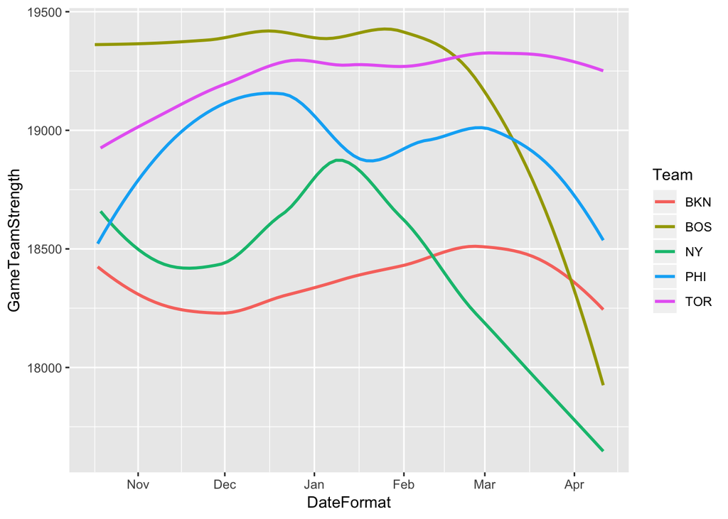

**Eastern Conference: Central Division**

- Chicago Bulls
  - 6.5GB of 8th, 16-27 in mid January, Zach Lavine injured, traded away Nikola Mirotic on February 1, finished 16GB of 8th, 13th in the conference, 3 games ahead of last place
  - Cristiano Felicio minutes up, Markannen (their rookie pick) minutes down, Robin Lopez, Kris Dunn didnt play towards end of season (had a concussion)

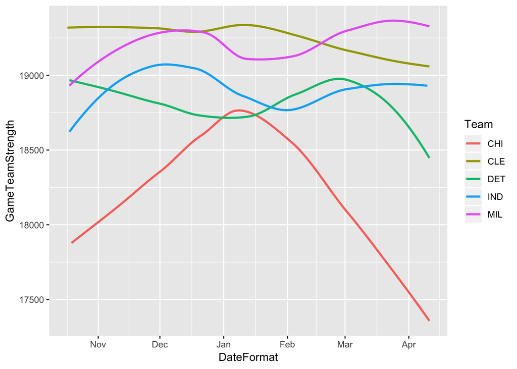

**Eastern Conference: Southeast Division**

- Atlanta Hawks
  - 15-36 at the end of January, sitting in last place of the Eastern conference (10GB of 8th), finished in last at 19GB (1 worse than the Orlando Magic)
  - John Collins (a rookie) - moved into starting lineup
  - Dewayne Dedmon - starting lineup
  - Schroder injured
  - More minutes for Taurean Prince
- Orlando Magic
  - At the end of February, the Magic had moved into last place of the Eastern Conference (18-43) going behind the Hawks (19-43). They finished the season 2nd to last 1GB ahead of the Hawks, no major trends amongst players minutes
- Washington Wizards
  - John Wall was sidelined for 2 months

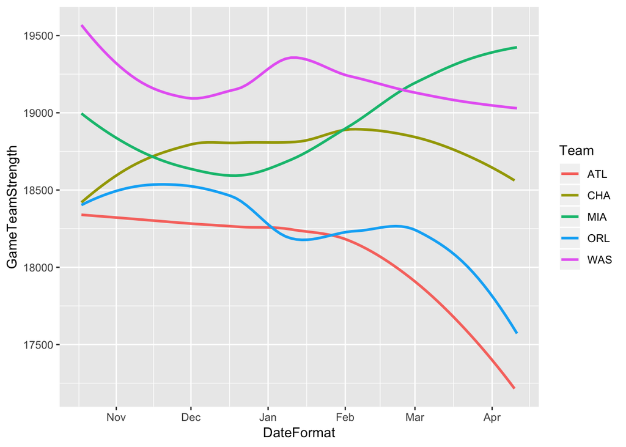

**Western Conference: Northwest Division**

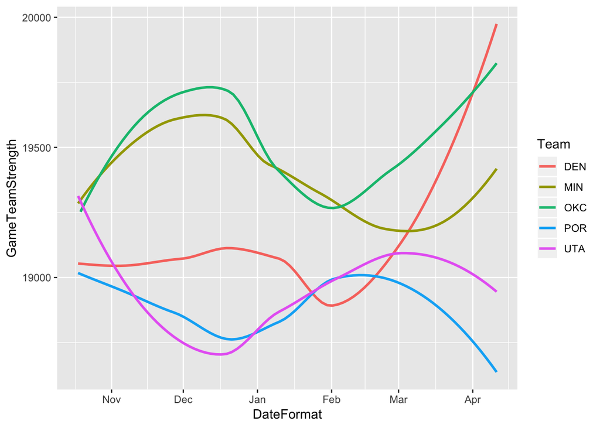

**Western Conference: Pacific Division**

- Golden State Warriors - as of February 1 they were 40-11
- Phoenix Suns - 18-41 and were last in Western Conference, went 3-20 in last 23 games
- Sacramento Kings - Moved into last 18-43, finished 27-55

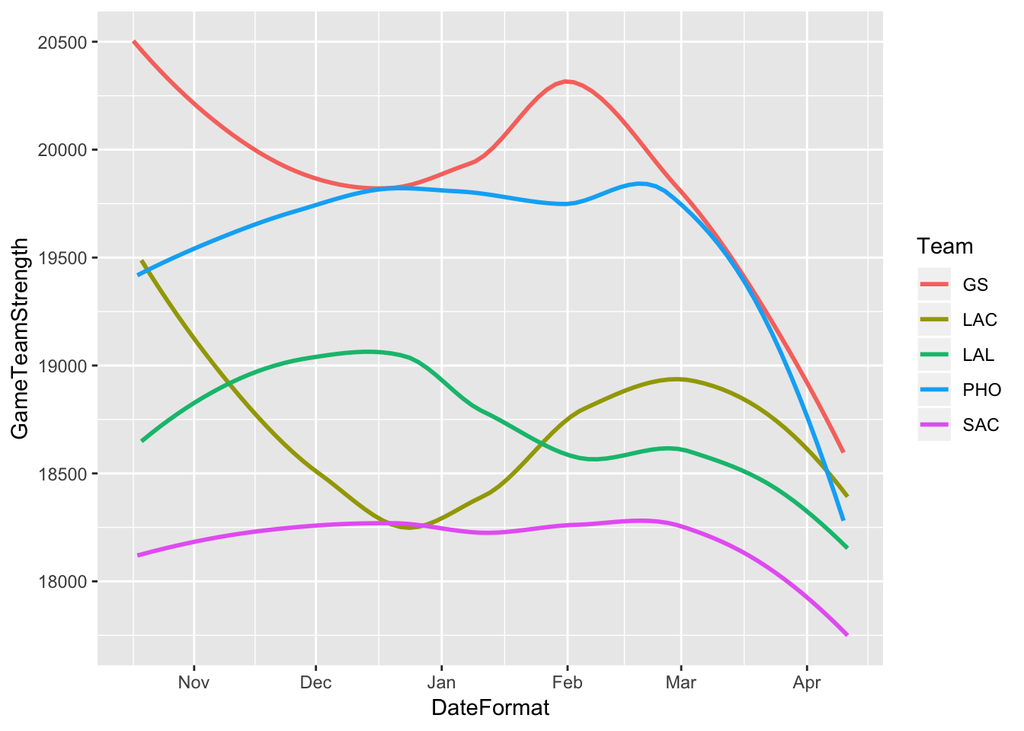

**Western Conference: Southwest Division**

- Dallas Mavericks - At the All Star Weekend they were 18-40 (.5 GB) from last, Dirk Nowitzki injured at end of season
- Memphis Grizzlies - Star player Mike Conley injured, 4-28 to end the season (12.5GB to 25GB), 2nd to last in Western Conference

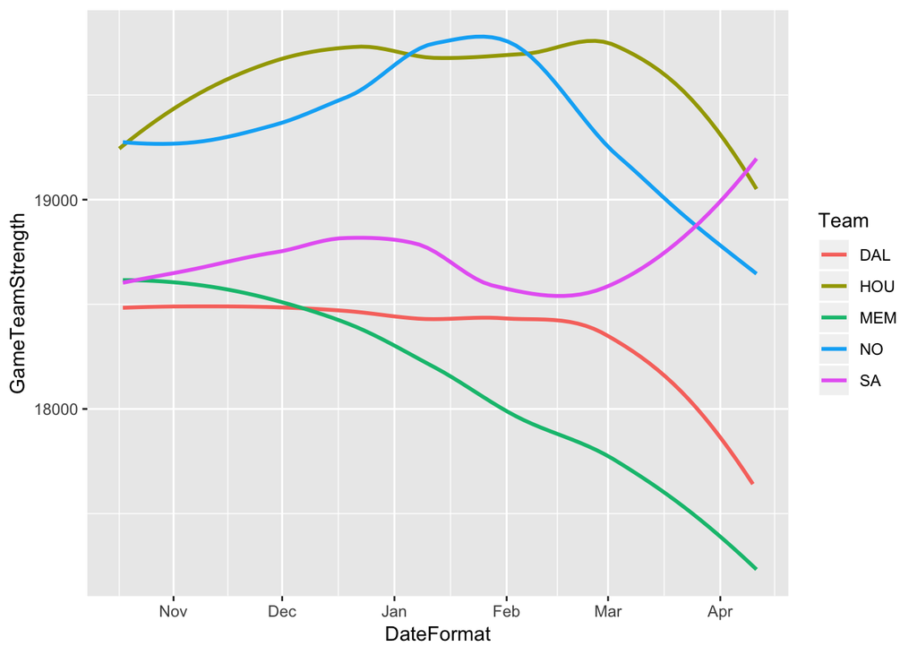

**Overview**

There were some limitations of these graphs. For some teams, it was not a deliberate attempt to lose but sometimes their star players got injured causing the curve to decline. For example, the Washington Wizards declined because of the injury to John Wall, the New York Knicks lost Kristaps Porzingis, and the Memphis Grizzlies lost Mike Conley.

Sometimes the graphs went upwards unexpectedly because of trades midseason or free agent signings. Dwyane Wade was signed by the Miami Heat, the Pistons received Blake Griffin (trade) which caused their team strength value to increase.

However, by analyzing individual box scores from midseason to the end of the season, we can see that some other players may have gotten more minutes.

## EDA for Winning Percentage & Streaks

**Winning Streaks**

```r
# INPUT:  3 character abbreviation of team name
# OUTPUT: vector of length 82

getTeamStrk <- function(teamName) {
  # Pipeline to get game date, team abbreviation, opponent abbreviation and game result attributes
  teamResults <- allBoxScores %>%
    filter(teamAbbr == teamName) %>%
    mutate(strkChange = ifelse(teamRslt == "Win", 1, -1)) %>%
    mutate(gameNum = 1:82)

  # Store run length encoding information for team wins/losses
  # Length of streak (1, 2, 3, ...)
  strkLengths <- rle(teamResults$strkChange)$lengths
  # Type of streak (-1 for loss /1 for win)
  strkTypes <- rle(teamResults$strkChange)$values
  # Expand vector of streaks into list of vectors
  # c(3, 2, 4) -> [c(1,2,3), c(1,2), c(1,2,3,4)]
  strkRuns <- sapply(strkLengths, function(i) seq(1, i))
  # Multiply each streak by its type
  strkSeason <- Map('*', strkRuns, strkTypes)
  # Collapse list of vectors into single vector
  strkSeason <- unlist(strkSeason)

  teamResults$currStrk = strkSeason

  return (teamResults)
}
```

```r
teams <- allBoxScores %>%
  select(teamAbbr)
# Remove duplicate teams
teams <- unique(teams)
# Sort tibble alphabetically by teamAbbr
teams <- sort(teams$teamAbbr)

allStreaksList <- bind_rows(invisible(lapply(teams, getTeamStrk)))
```

**Combining Everything into One Dataframe**

```r
names(teamstrength)[names(teamstrength) == 'DateFormat'] <- 'gmDate'
names(teamstrength)[names(teamstrength) == 'Team'] <- 'teamAbbr'
# Join "Game Strength" data frame with "Streaks" data frame
master_df <- merge(allStreaksList, teamstrength, by = c("gmDate", "teamAbbr"))

master_df <- master_df %>%
  mutate(won = ifelse(strkChange == 1, 1, 0))

master_df$currWins <- ave(master_df$won, master_df$teamAbbr, FUN = cumsum)

library(plyr)

master_df <- master_df %>%
  mutate(winningPer = currWins / gameNum) %>%
  mutate(meanStrength=mean(GameTeamStrength), stStrength=sd(GameTeamStrength), standardizedStrength = (GameTeamStrength - meanStrength)/stStrength)
master_df <- ddply(master_df, c("teamAbbr"), transform, winningPer.std = scale(winningPer))

master_df %>%
  head()
```

```
##       gmDate teamAbbr teamConf   teamDiv teamRslt strkChange gameNum
## 1 2017-10-18      ATL     East Southeast      Win          1       1
## 2 2017-10-20      ATL     East Southeast     Loss         -1       2
## 3 2017-10-22      ATL     East Southeast     Loss         -1       3
## 4 2017-10-23      ATL     East Southeast     Loss         -1       4
## 5 2017-10-26      ATL     East Southeast     Loss         -1       5
## 6 2017-10-27      ATL     East Southeast     Loss         -1       6
##   currStrk GameTeamStrength won currWins winningPer meanStrength
## 1        1            18452   1        1  1.0000000     18897.19
## 2       -1            18412   0        1  0.5000000     18897.19
## 3       -2            18350   0        1  0.3333333     18897.19
## 4       -3            18118   0        1  0.2500000     18897.19
## 5       -4            18108   0        1  0.2000000     18897.19
## 6       -5            18563   0        1  0.1666667     18897.19
##   stStrength standardizedStrength winningPer.std
## 1   797.4766           -0.5582467      7.2674817
## 2   797.4766           -0.6084049      2.3111500
## 3   797.4766           -0.6861501      0.6590395
## 4   797.4766           -0.9770677     -0.1670158
## 5   797.4766           -0.9896073     -0.6626490
## 6   797.4766           -0.4190576     -0.9930711
```

## Clustering Teams

For the last part of this tutorial, we’ll try to cluster teams based on the main two attributes that we identified in the beginning - team strength and winning percentage.

Tanking has become such a common issue among the league’s worst performing teams. For further analysis, we plan on looking at past seasons and checking if the number of teams in the bottom left quadrant has increased.

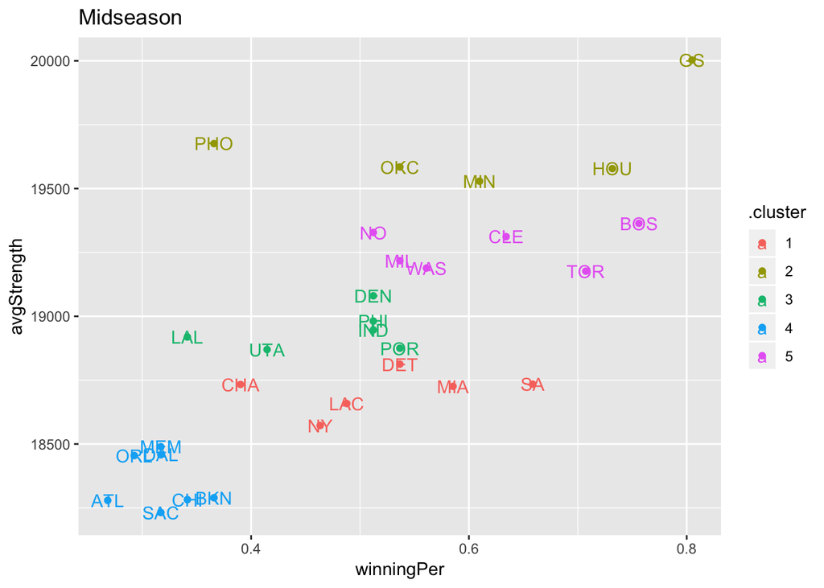

```r
library(class)
library(broom)

midseason_df <- master_df %>%
  filter(gameNum <= 41)
midseason_df$avgStrength <- ave(midseason_df$GameTeamStrength, midseason_df$teamAbbr)

end_df <- master_df %>%
  filter(41 < gameNum)
end_df$avgStrength <- ave(end_df$GameTeamStrength, end_df$teamAbbr)

# Midseason
midseason_single <- midseason_df %>%
  filter(gameNum == 41)

midseason_kmeans <- midseason_single %>%
  select(winningPer, avgStrength) %>%
  kmeans(centers = 5)

midseason_clustered <- midseason_kmeans %>%
  augment(data = midseason_single) %>%
  as_tibble()

midseason_kmeans_centers <- midseason_kmeans %>%
  tidy() %>%
  as_tibble()

# midseason_clustered %>%
#  select(teamAbbr, winningPer, avgStrength, .cluster) %>%
#  arrange(.cluster) %>%
#  knitr::kable()

# End of Season
end_single <- end_df %>%
  filter(gameNum == 82)

end_kmeans <- end_single %>%
  select(winningPer, avgStrength) %>%
  kmeans(centers = 5)

end_clustered <- end_kmeans %>%
  augment(data = end_single) %>%
  as_tibble()

end_kmeans_centers <- end_kmeans %>%
  tidy() %>%
  as_tibble()

# end_clustered %>%
#  select(teamAbbr, winningPer, avgStrength, .cluster) %>%
#  arrange(.cluster) %>%
#  knitr::kable()

midseason_clustered %>%
  ggplot(mapping = aes(x = winningPer, y = avgStrength, color=.cluster)) +
  geom_point() +
  geom_text(aes(label = teamAbbr)) +
  ggtitle("Midseason")
```

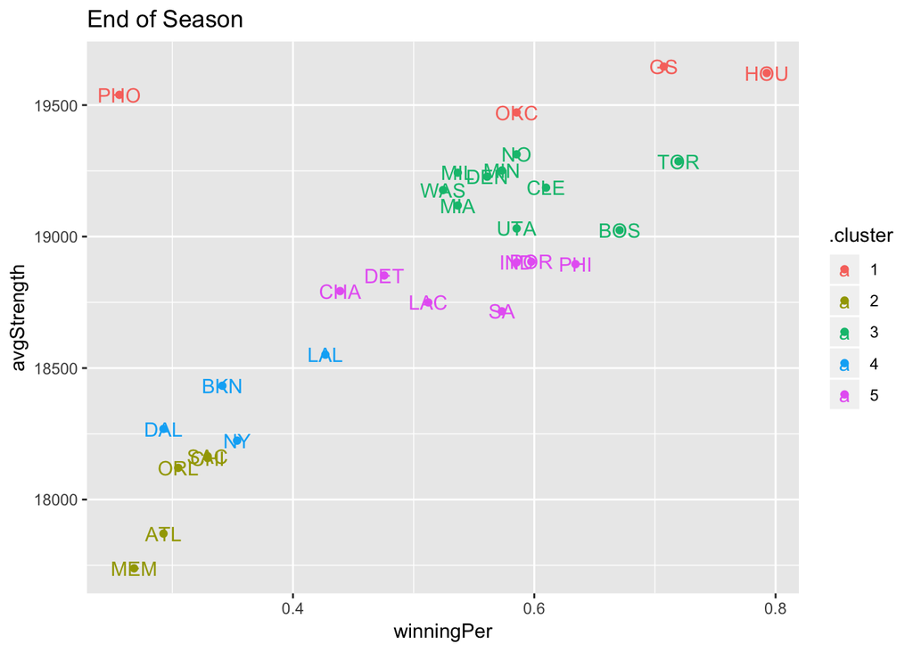

```r
end_clustered %>%
  ggplot(mapping = aes(x = winningPer, y = avgStrength, color=.cluster)) +
  geom_point() +
  geom_text(aes(label = teamAbbr)) +
  ggtitle("End of Season")
```

## Conclusion

**Tanking Teams**

In the bottom left, we have teams that have weak rosters (low average strength score) and a low winning percentage. We believe that these are the teams that are actively tanking. At the mid-season point, these teams are all pretty close each other. However, at the end of the season, the distance between the points in this cluster increases. This is likely due to the fact that the Memphis Grizzlies (MEM) and Atlanta Hawks (ATL) were playing significantly worse rosters than they were playing during the first half of the season as they “competed” for the worst record in the NBA.

Note that the New York Knicks (NY) joined this cluster in the second half of the season. Based on reports about the team during the season, this is probably due to Kristaps Porzingis’ injury.

**Middle of the Pack Teams**

These teams are around the center but have an average strength score lower than 19,000 and a winning percentage between 0.4 and 0.6. In the mid-season and end of season graphs, they’re represented by two clusters and one cluster respectively. These seem to be the fringe playoff teams that were too competitive to commit to tanking but not good enough to make the playoffs.

**Playoff Teams**

These teams seem to have strengths between 19,000 and 19,500 and are the teams that qualified for the playoffs at the lower seeds.

**Elite Teams**

Out of these teams, the Phoneix Suns seem to be out of place as they’re widely regarded as a tanking team. However, they have a unusally high team strength that is an outlier for a team that wins as few games as they do. This passes the santity test according to articles like [this](https://theshadowleague.com/after-tanking-to-a-21-61-season-the-suns-land-the-no-1-draft-pick/).